# Exploring Random Forests with ggRandomForests

John Ehrlinger

2026-07-02

A fitted random forest carries a lot of information, but getting at it usually means digging through list structures that were never meant to be plotted directly. **ggRandomForests** does that digging for you: it pulls tidy data objects out of a `randomForestSRC` or `randomForest` fit, and those objects drop straight into the `ggplot2` workflows you already know. A second engine, `varPro`, powers a parallel family of functions for release-rule importance and related diagnostics; that family is covered in the companion vignette referenced at the end. This vignette walks through the three objects you will reach for most often (`gg_error`, `gg_variable`, and `gg_vimp`), plus a small helper for cutting a predictor into evenly populated groups.

## Error trajectories with `gg_error()`

```r
library(randomForest)
set.seed(42)
rf_iris <- randomForest(Species ~ ., data = iris, ntree = 200, keep.forest = TRUE)
err_df <- ggRandomForests::gg_error(rf_iris, training = TRUE)
head(err_df)
```

```
<gg_error>  from randomForest  |  family: classification  |  ntree: 200  |  n: 150
```

A forest’s error rate settles down as trees are added, and the `gg_error()` object lets you watch that happen. It holds the cumulative out-of-bag (OOB) error rate for each outcome column, indexed by the `ntree` counter. Ask for `training = TRUE` and the function reconstructs the original model frame and adds the in-bag error trajectory (`train`) as well, so you can see both curves at once:

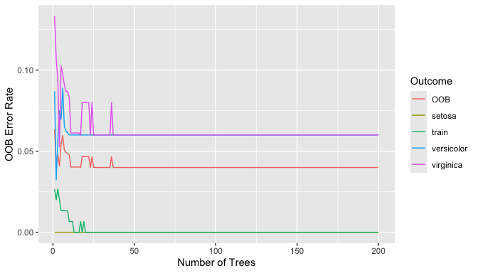

```r
plot(err_df)
```

## Marginal dependence via `gg_variable()`

```r
set.seed(99)
boston <- MASS::Boston
rf_boston <- randomForest(medv ~ ., data = boston, ntree = 150)
var_df <- ggRandomForests::gg_variable(rf_boston)
str(var_df[, c("lstat", "yhat")])
```

```
Classes 'gg_variable', 'regression' and 'data.frame':   506 obs. of  2 variables:
 $ lstat: num  4.98 9.14 4.03 2.94 5.33 ...
 $ yhat : num  27.7 23.3 34.6 36.4 33.6 ...
```

`gg_variable()` recovers the training data straight from the model call, so it still works when the forest was fit inside a helper function or against a `subset()` expression, cases where the data is not sitting in the global environment. The object you get back keeps the raw predictors alongside the prediction: a single `yhat` column for regression, or one `yhat.<class>` column per class for classification. To plot one predictor, name it with `xvar`:

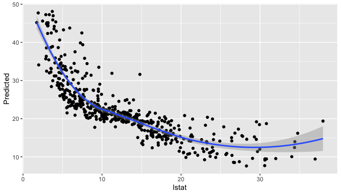

```r
plot(var_df, xvar = "lstat")
```

Survival forests can request multiple horizons using the `time` argument; non-OOB predictions are available by setting `oob = FALSE`.

## Variable importance with `gg_vimp()`

```r
vimp_df <- ggRandomForests::gg_vimp(rf_boston)
head(vimp_df)
```

[output not shown]

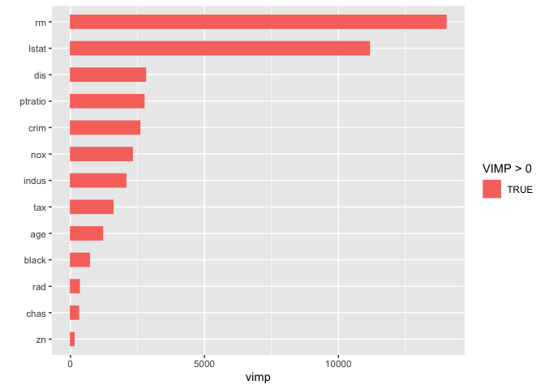

```r
plot(vimp_df)
```

## Balanced conditioning cuts with `quantile_pts()`

```r
rm_breaks <- ggRandomForests::quantile_pts(boston$rm, groups = 6, intervals = TRUE)
rm_groups <- cut(boston$rm, breaks = rm_breaks)
table(rm_groups)
```

```
rm_groups
(3.56,5.76] (5.76,5.99] (5.99,6.21] (6.21,6.44] (6.44,6.85] (6.85,8.78]
         85          84          84          85          84          84
```

When you build a coplot, you want each conditioning group to hold a roughly equal share of the data — equal-width bins leave the sparse tails nearly empty. `quantile_pts()` wraps `stats::quantile()` to give you break points that do exactly that, and they pass straight to `cut()` for the grouping or facet labels.

## Next steps

- The full API reference lives at https://ehrlinger.github.io/ggRandomForests/.
- `?gg_error`, `?gg_variable`, `?gg_vimp`, and `?quantile_pts` cover the remaining arguments and have their own examples.
- The `gg_error`, `gg_variable`, and `gg_vimp` objects shown here are tidy data frames underneath, so you can skip the `plot()` methods entirely and build the figure yourself with `ggplot2`.
- For the full varPro toolkit (release-rule importance, lasso-refined importance, per-observation local importance, anomaly scores, and the dependency graph) walked across regression, classification, and survival examples, see `vignette("varpro", package = "ggRandomForests")`.